# Full analysis - Coralie dataset

Jacques Marc-Antoine

8 août 2017

# 1 Load data and functions

Define the `Ratio` column as the ratio of fluo intensity in cytosol over nucleus.

```r
source("../rscripts/dist_mean.R")
source("../rscripts/overlap_clipping.R")
source("../rscripts/all_pairwise_stat.R")
source("../rscripts/sim_data.R")
source("../rscripts/amplitude_oscillations.R")
source("../rscripts/separability.R")

Cora <- fread("C:/Users/pixel/Dropbox/Marc-Antoine/data/set1-Coralie/tCoursesSelected.csv")
Cora[, Ratio := objCyto_Intensity_MeanIntensity_imErkCorrOrig / objNuc_Intensity_MeanIntensity_imErkCorrOrig]
setkey(Cora, Image_Metadata_Site, objNuc_TrackObjects_Label)
```

Trajectories are represented below:

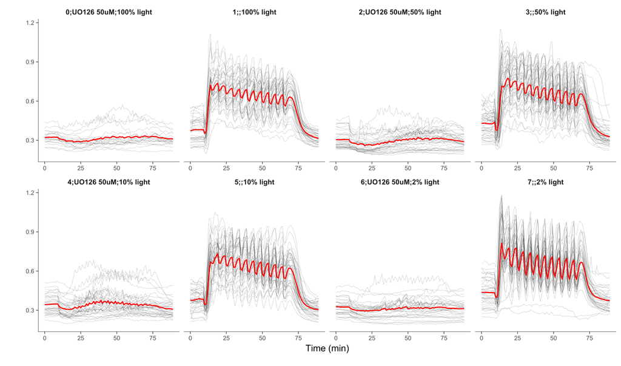

Dataset is divided in 8 conditions, with presence/absence of inhibitor and various stimulus intensities.

# 2 Assess synchrony of the trajectories

## 2.1 Compute the metrics

First we want a metric to define how synchronous trajectories are. We use 5 measures:

- Euclidean distance between individual trajectories and mean trajectory of the condition.
- Pairwise overlap of clipped trajectories (clipping: 1 if signal is increasing, 0 if signal is decreasing).
- Pairwise correlations of the trajectories in a condition (Pearson, Spearman based on ranks, Kendall based on concordant pairs)

k_roll_mean represents the width of the window for the rolling mean and should be set to the number of points per oscillation. Here in all oscillatory conditions, the period is roughly of 5 min (1 point/min).

```r
cond <- "Image_Metadata_Site"
tcol <- "RealTime"
mea <- "Ratio"
lab <- "objNuc_TrackObjects_Label"

Cora_mean <- dist_mean(data = Cora, condition = cond, tcol = tcol, measure = mea, label = lab, return.mean = F)
Cora_mean
```

```
##      Image_Metadata_Site objNuc_TrackObjects_Label euclid_to_mean
##   1:                   0                         1      0.1998347
##   2:                   0                         2      0.2956778
##   3:                   0                         3      1.3154587
##   4:                   0                         4      0.3064825
##   5:                   0                         5      0.9195408
##  ---
## 299:                   7                        41      1.9014643
## 300:                   7                        42      2.8330774
## 301:                   7                        43      0.5476504
## 302:                   7                        44      1.6509783
## 303:                   7                        45      0.6624683
```

```r
Cora_pw <- all_pairwise_stats(data = Cora, condition = cond, label = lab, measure = mea, k_roll_mean = 5)
Cora_pw
```

```
##       Image_Metadata_Site Label1 Label2   Overlap     Pearson    Spearman     Kendall
##    1:                   0      1      2 0.6777778  0.05118725  0.06139853  0.04519351
##    2:                   0      1      3 0.6111111  0.15680425  0.13959748  0.08364544
##    3:                   0      1      4 0.5000000  0.54887095  0.26219698  0.17053683
##    4:                   0      1      5 0.6222222  0.67687971  0.66318476  0.46516854
##    5:                   0      1      6 0.6222222 -0.50119239 -0.49462074 -0.31435705
##   ---
## 5795:                   7     42     44 0.5888889  0.24703464  0.28443841  0.17253433
## 5796:                   7     42     45 0.6555556  0.18813077  0.23007779  0.15056180
## 5797:                   7     43     44 0.8000000  0.92516460  0.94486562  0.81173533
## 5798:                   7     43     45 0.8222222  0.80578702  0.84934766  0.66591760
## 5799:                   7     44     45 0.8666667  0.92830614  0.91943038  0.74232210
```

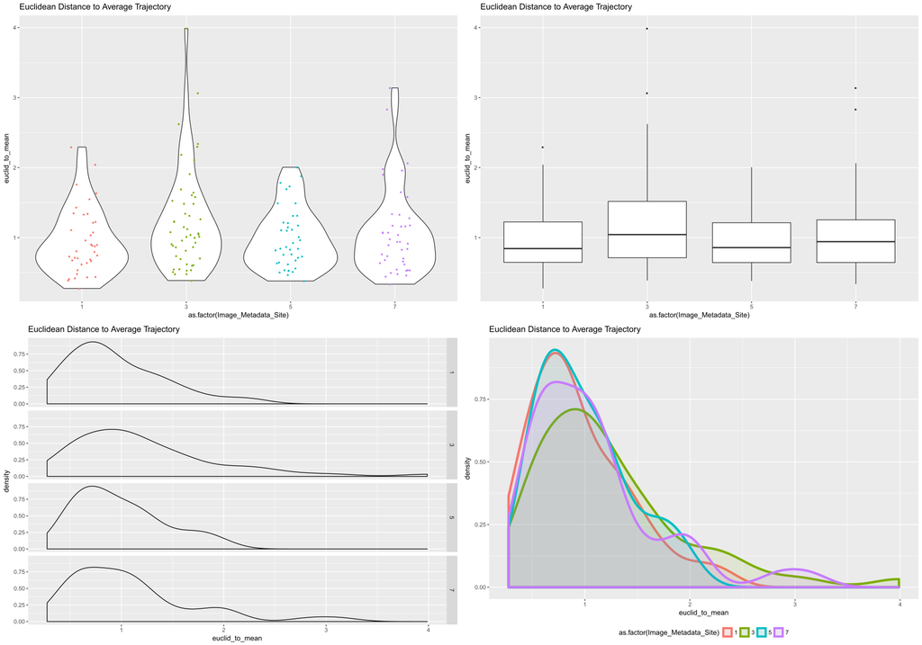

Euclidean distance to mean trajectory

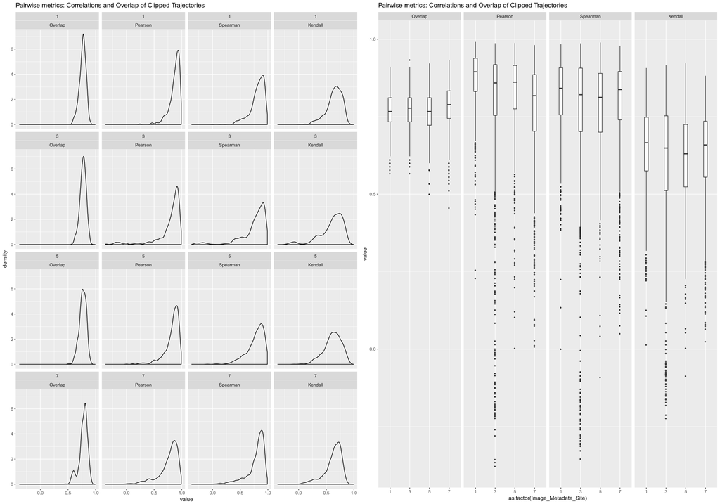

Pairwise metrics

## 2.2 Difference between distributions

Several possibilities here:

### 2.2.1 Distance to mean trajectory

```r
conds <- 0:7
comb <- combn(conds, 2)

sep.matrix <- matrix(unlist(
  apply(comb, 2, function(x) separability.measures(Cora_mean[Image_Metadata_Site==x[1], euclid_to_mean], Cora_mean[Image_Metadata_Site==x[2], euclid_to_mean])))
  , ncol=5, byrow = T)

sep.matrix <- cbind(t(comb), sep.matrix)
colnames(sep.matrix) <- c("Condition1", "Condition2", "jm", "bh", "div", "tdiv", "ks")
sep.matrix
```

```
##       Condition1 Condition2          jm          bh         div        tdiv        ks
##  [1,]          0          1 0.264510749 0.141857818  1.20640371 0.279961427 0.4976077
##  [2,]          0          2 0.892777904 0.591292918 19.26848834 1.820110744 0.3492823
##  [3,]          0          3 0.515068063 0.297778243  3.41202204 0.694423865 0.6163636
##  [4,]          0          4 0.042820938 0.021642998  0.17835883 0.044096320 0.3009828
##  [5,]          0          5 0.317417296 0.172817244  1.41604463 0.324449779 0.6113636
##  [6,]          0          6 0.006981907 0.003497061  0.02803818 0.006997275 0.1994949
##  [7,]          0          7 0.388250475 0.215826930  2.16846876 0.474856375 0.5887446
##  [8,]          1          2 0.737624732 0.460152101 10.60073259 1.468442761 0.3157895
##  [9,]          1          3 0.135577875 0.070196028  0.63416766 0.152420834 0.2452632
## [10,]          1          4 0.103543681 0.053160131  0.42682881 0.103910553 0.4651494
## [11,]          1          5 0.006517125 0.003263883  0.02627197 0.006557220 0.1342105
## [12,]          1          6 0.192479838 0.101191351  0.84277512 0.199975474 0.4839181
## [13,]          1          7 0.050268443 0.025455481  0.21346393 0.052660291 0.1528822
## [14,]          2          3 0.484135362 0.277161186  4.06033467 0.796052975 0.4042105
## [15,]          2          4 0.780023275 0.494315400 12.44101958 1.577675062 0.2019915
## [16,]          2          5 0.794084304 0.505907988 13.13150631 1.612597513 0.3315789
## [17,]          2          6 0.863814847 0.565470887 17.18936441 1.766721759 0.2953216
## [18,]          2          7 0.574922959 0.338921304  5.75883545 1.026353766 0.3170426
## [19,]          3          4 0.317659048 0.172960933  1.67389850 0.377594592 0.5308108
## [20,]          3          5 0.166330621 0.086828096  0.82057357 0.194973119 0.2000000
## [21,]          3          6 0.443604973 0.250774914  2.73319595 0.578805541 0.5788889
## [22,]          3          7 0.023612658 0.011876577  0.09667273 0.024022745 0.1380952
## [23,]          4          5 0.140825738 0.073014737  0.58499806 0.141030275 0.4756757
## [24,]          4          6 0.017653912 0.008866144  0.07199585 0.017918215 0.1741742
## [25,]          4          7 0.201515476 0.106202801  0.93424806 0.220439947 0.4613900
## [26,]          5          6 0.235741409 0.125416640  1.01480309 0.238269094 0.5638889
## [27,]          5          7 0.074125438 0.037766998  0.32584058 0.079823502 0.1178571
## [28,]          6          7 0.316443433 0.172238620  1.66158206 0.375094886 0.5198413
```

If we represent only the oscillating conditons:

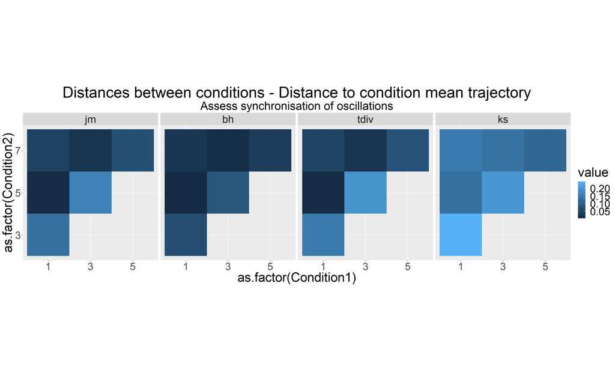

### 2.2.2 Overlap of clipped trajectories and pairwise correlations

We can for each of the 4 pairwise measures (overlap and 3 types of correlation) get a separability matrix just like above. (code hidden for the sake of clarity)

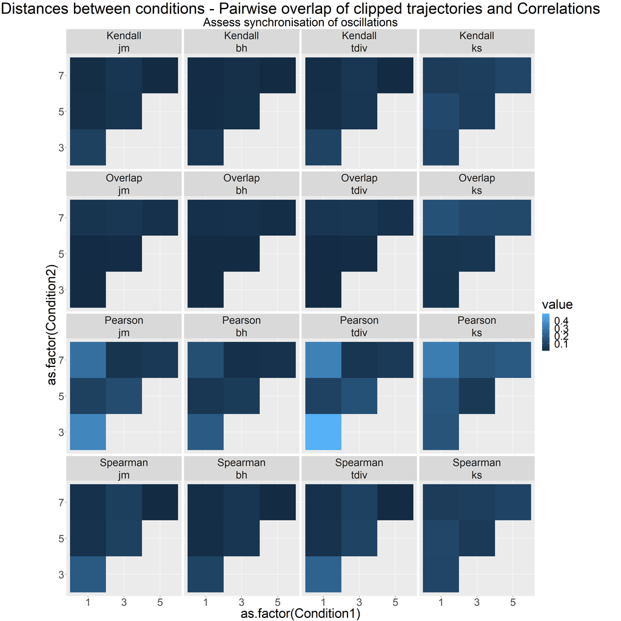

Essentially we see that in all oscillating conditions (1,3,5,7), trajectories are well synchronised and simply follow the stimulation rate (one pulse every 5min).

# 3 Assess amplitude differences

## 3.1 Euclidean distance to individual rolling mean

Another difference between these time series is the amplitude of the oscillations (when they are present). To assess this we measure for each individual trajectory its Euclidean distance to its OWN rolling mean. If set properly without a too important trend, the rolling mean “cut oscillations in 2” and has thus a null variation over an oscillation.

```r
Cora_amp <- amplitude_oscillations(data = Cora, condition = cond, label = lab, measure = mea, k_roll_mean = 5)
```

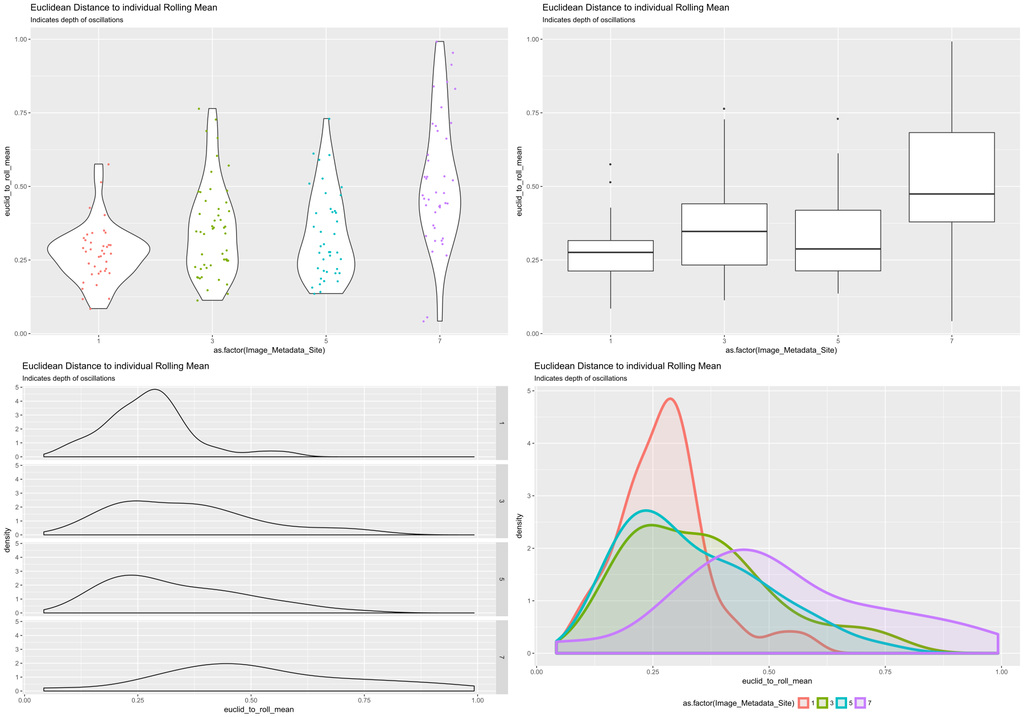

Euclidean distance to individual rolling trajectory

We can again use the previous metrics to quantify the differences between the distributions:

```r
sep.matrix <- matrix(unlist(
  apply(comb, 2, function(x) separability.measures(Cora_amp[Image_Metadata_Site==x[1], euclid_to_roll_mean], Cora_amp[Image_Metadata_Site==x[2], euclid_to_roll_mean])))
  , ncol=5, byrow = T)

sep.matrix <- cbind(t(comb), sep.matrix)
colnames(sep.matrix) <- c("Condition1", "Condition2", "jm", "bh", "div", "tdiv", "ks")
sep.matrix
```

```
##       Condition1 Condition2          jm          bh          div        tdiv        ks
##  [1,]          0          1 1.539908569 1.469477227  35.43882414 1.976167518 0.9282297
##  [2,]          0          2 1.148258418 0.853619287  58.77039155 1.998710050 0.1746411
##  [3,]          0          3 1.504908045 1.396158947  66.97639706 1.999537518 0.9800000
##  [4,]          0          4 0.145741182 0.075662123   0.68456770 0.164024004 0.2678133
##  [5,]          0          5 1.486885795 1.360404017  59.09293453 1.998761023 1.0000000
##  [6,]          0          6 0.011732031 0.005883288   0.04756745 0.011856580 0.3055556
##  [7,]          0          7 1.661236318 1.775599699 151.81002631 1.999999989 0.9523810
##  [8,]          1          2 0.586194763 0.346862362   5.80494883 1.031949886 0.8684211
##  [9,]          1          3 0.187216402 0.098283617   0.91960340 0.217179332 0.3884211
## [10,]          1          4 1.278703293 1.019851885  13.86595561 1.646579697 0.8677098
## [11,]          1          5 0.133396199 0.069026550   0.61948355 0.149026463 0.2947368
## [12,]          1          6 1.521693930 1.430651618  28.72890660 1.944864757 0.9459064
## [13,]          1          7 0.658955510 0.399698400   5.19422472 0.955154434 0.6804511
## [14,]          2          3 0.416536366 0.233532559   2.67241872 0.567967391 0.9073684
## [15,]          2          4 0.952155328 0.646411820  24.54116713 1.906938872 0.1927454
## [16,]          2          5 0.423606763 0.238007704   2.84524101 0.598571527 0.9223684
## [17,]          2          6 1.094605951 0.792532197  45.58915947 1.993298995 0.2266082
## [18,]          2          7 0.537504771 0.313003142   2.85716902 0.600659502 0.9260652
## [19,]          3          4 1.310065061 1.064305158  26.55763741 1.927672980 0.9129730
## [20,]          3          5 0.005663713 0.002835874   0.02275980 0.005681865 0.1250000
## [21,]          3          6 1.482399955 1.351699629  53.25540440 1.997429817 0.9722222
## [22,]          3          7 0.223112019 0.118283672   1.03979145 0.243763357 0.4542857
## [23,]          4          5 1.280004632 1.021657681  23.29757295 1.891287602 0.8979730
## [24,]          4          6 0.125536947 0.064824934   0.55602802 0.134286267 0.3633634
## [25,]          4          7 1.537050111 1.463283642  62.13730215 1.999153174 0.9523810
## [26,]          5          6 1.464037237 1.316837773  47.07740789 1.994436505 0.9722222
## [27,]          5          7 0.288814844 0.155960976   1.42309536 0.325925859 0.4892857
## [28,]          6          7 1.644555529 1.727533421 119.71875983 1.999999366 0.9523810
```

If we represent only the oscillating conditons:

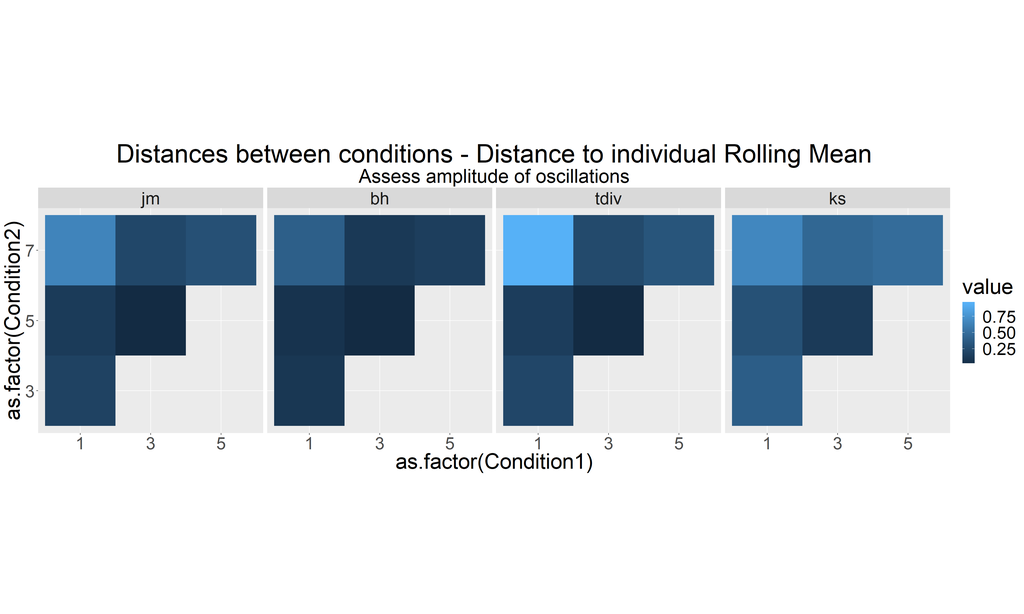

## 3.2 Power of oscillation frequency

For this we will assume that all conditions oscillate at the same frequency, 0.2. The idea is to get the height of the peak for each trajectory in its power spectrum at this specific frequency.

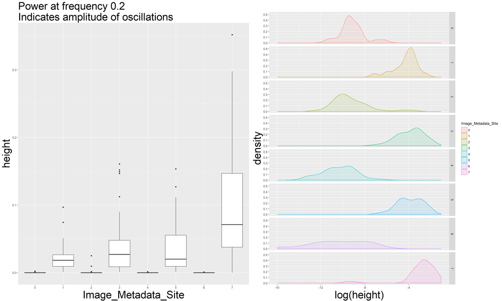

```r
# this doesn't work, but because freq 0.2 is always in 18th position so far...
#power_height <- Cora[, .(height = spectrum(Ratio, plot=F)$spec[which(spectrum(Ratio, plot = F)$freq == 0.2)]), by = c(cond, lab)]
power_height <- Cora[, .(height = spectrum(Ratio, plot=F)$spec[18]), by = c(cond, lab)]
power_height[, c("Image_Metadata_Site", "objNuc_TrackObjects_Label") := list(as.factor(Image_Metadata_Site), as.factor(objNuc_TrackObjects_Label))]

library(gridExtra)
p1 <- ggplot(power_height, aes(x= Image_Metadata_Site, y = height)) + geom_boxplot(aes(group=Image_Metadata_Site)) + ggtitle("Power at frequency 0.2", "Indicates amplitude of oscillations") + theme(axis.title = element_text(size = 30), plot.title = element_text(size = 30), plot.subtitle = element_text(size = 30))
p2 <- ggplot(power_height, aes(x = log(height), fill = Image_Metadata_Site, colour = Image_Metadata_Site)) + geom_density(alpha=0.1) + ggtitle("","") + facet_grid(Image_Metadata_Site ~ .) + theme(axis.title = element_text(size = 30))
grid.arrange(p1, p2, ncol = 2)
```

```r
sep.matrix <- matrix(unlist(
  apply(comb, 2, function(x) separability.measures(power_height[Image_Metadata_Site==x[1], height], power_height[Image_Metadata_Site==x[2], height])))
  , ncol=5, byrow = T)

sep.matrix <- cbind(t(comb), sep.matrix)
colnames(sep.matrix) <- c("Condition1", "Condition2", "jm", "bh", "div", "tdiv", "ks")
sep.matrix
```

```
##       Condition1 Condition2         jm          bh          div        tdiv        ks
##  [1,]          0          1 1.67991362 1.832311567 1.993856e+03 2.000000000 0.9473684
##  [2,]          0          2 1.08727833 0.784471479 4.408023e+01 1.991908023 0.3181818
##  [3,]          0          3 1.76205630 2.128868383 7.823374e+03 2.000000000 0.9600000
##  [4,]          0          4 0.27556217 0.148246080 1.609013e+00 0.364382350 0.4127764
##  [5,]          0          5 1.75352596 2.093645796 6.565143e+03 2.000000000 0.9750000
##  [6,]          0          6 0.10364331 0.053212666 4.743618e-01 0.115143011 0.4570707
##  [7,]          0          7 1.85199683 2.603668780 3.788913e+04 2.000000000 0.9523810
##  [8,]          1          2 1.01045908 0.703661344 2.159013e+01 1.865422975 0.9210526
##  [9,]          1          3 0.31595164 0.171946549 1.940403e+00 0.430751496 0.3347368
## [10,]          1          4 1.78096483 2.211670158 9.018084e+03 2.000000000 0.9729730
## [11,]          1          5 0.25174583 0.134529506 1.400206e+00 0.321129277 0.2947368
## [12,]          1          6 1.74636373 2.065001220 5.046419e+03 2.000000000 0.9473684
## [13,]          1          7 0.90506358 0.602450884 1.565846e+01 1.717523540 0.6616541
## [14,]          2          3 1.26910041 1.006626364 8.770964e+01 1.999965362 0.9273684
## [15,]          2          4 1.37237779 1.158964055 2.039800e+02 2.000000000 0.3022760
## [16,]          2          5 1.24220238 0.970486098 7.337920e+01 1.999792266 0.9223684
## [17,]          2          6 1.27419227 1.013617308 1.132175e+02 1.999998572 0.3362573
## [18,]          2          7 1.54548945 1.481681323 4.313447e+02 2.000000000 0.9260652
## [19,]          3          4 1.83678946 2.505861458 3.524649e+04 2.000000000 0.9800000
## [20,]          3          5 0.00666775 0.003339445 2.689075e-02 0.006711401 0.1100000
## [21,]          3          6 1.81132986 2.360902252 1.977745e+04 2.000000000 0.9800000
## [22,]          3          7 0.36594874 0.202084815 2.195978e+00 0.480091891 0.4942857
## [23,]          4          5 1.83097901 2.470879536 2.958922e+04 2.000000000 0.9750000
## [24,]          4          6 0.07680054 0.039156994 3.328691e-01 0.081509749 0.2800300
## [25,]          4          7 1.89843335 2.980187210 1.704183e+05 2.000000000 0.9523810
## [26,]          5          6 1.80457921 2.325747310 1.659856e+04 2.000000000 1.0000000
## [27,]          5          7 0.43984912 0.248364647 2.963688e+00 0.619167994 0.4785714
## [28,]          6          7 1.88263064 2.835576532 9.573511e+04 2.000000000 0.9523810
```

If we represent only the oscillating conditons:

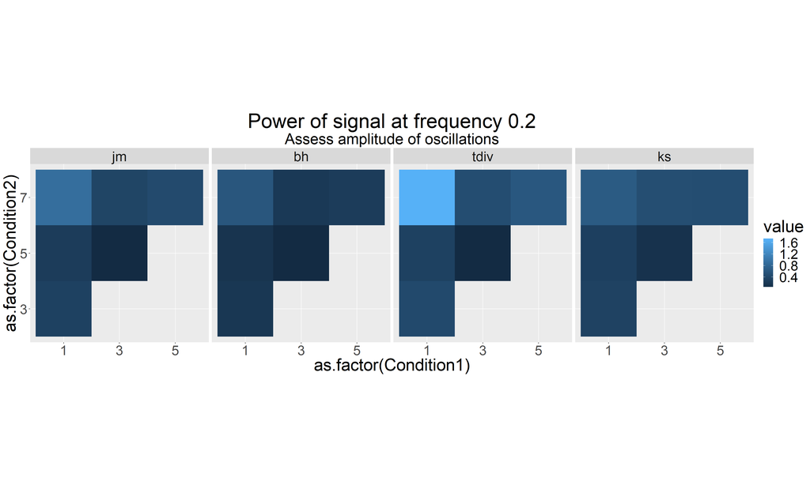

# 4 Alternative: SMETS

Method that compare directly conditions and assign a distance between them. It is based on the sum of Euclidean distances between matched trajectories, to which penalization is added to account for unmacthed trajectories. The penalization is proportionnal to the number of unmatched ts and to their information content (entropy).

Provided in a Matlab script (can run it with octave), results are:

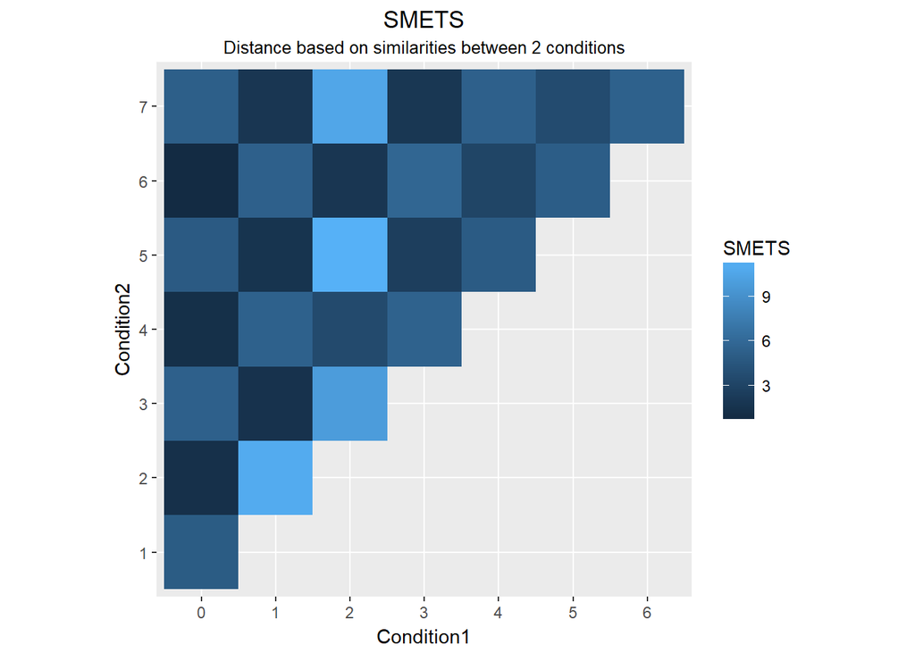

```r
smets
```

```
##     Condition1 Condition2    SMETS
##  1:          0          1  4.98900
##  2:          0          2  1.36520
##  3:          0          3  5.37220
##  4:          0          4  1.32590
##  5:          0          5  4.89370
##  6:          0          6  0.90025
##  7:          0          7  5.28130
##  8:          1          2 10.95500
##  9:          1          3  1.53050
## 10:          1          4  5.41430
## 11:          1          5  1.67200
## 12:          1          6  5.36890
## 13:          1          7  1.87920
## 14:          2          3  9.87540
## 15:          2          4  3.55650
## 16:          2          5 11.37500
## 17:          2          6  1.90830
## 18:          2          7 10.59600
## 19:          3          4  5.50970
## 20:          3          5  2.60150
## 21:          3          6  5.81990
## 22:          3          7  1.96180
## 23:          4          5  4.94870
## 24:          4          6  3.13040
## 25:          4          7  5.37510
## 26:          5          6  5.13420
## 27:          5          7  3.68440
## 28:          6          7  5.43590
##     Condition1 Condition2    SMETS
```

# 5 Cross-Correlation stimulations vs trajectories

Find the best lag to align stimulus and signal. This gives the best possible correlation as well as the response time of the cells.

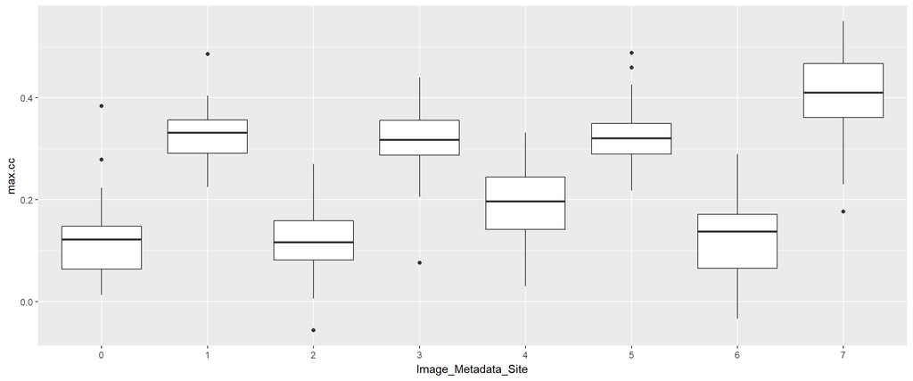

```r
get.max.cc <- function(ts1, ts2, plot = F, ...){
  temp <- ccf(ts1, ts2, plot = plot, ...)
  max.indx <- which.max(temp$acf)
  return(list(temp$acf[max.indx], temp$lag[max.indx]))
}

# Time series representing the stimuli, here one pulse every 5min starting at 11min til 66min
stim <- rep(0, 90)
stim[seq(11,66,5)] <- 1

cc.stim <- copy(Cora)
cc.stim[, c("max.cc", "best.lag") := get.max.cc(Ratio, stim, plot = F), by = .(Image_Metadata_Site, objNuc_TrackObjects_Label)]
cc.stim[, c("Image_Metadata_Site", "objNuc_TrackObjects_Label") := list(as.factor(Image_Metadata_Site), as.factor(objNuc_TrackObjects_Label))]

ggplot(cc.stim, aes(x = Image_Metadata_Site, y = max.cc)) + geom_boxplot(aes(group=Image_Metadata_Site))
```

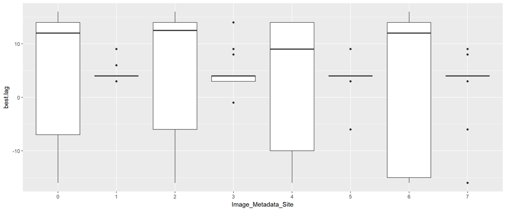

```r
ggplot(cc.stim, aes(x = Image_Metadata_Site, y = best.lag)) + geom_boxplot(aes(group=Image_Metadata_Site))
```

We see that the correlation between pulses and condition 7 is bigger than for the other ones, what shows that there is globally less noise in these trajectories. In addition we see that for the cyclic conditions the lag before max response is always of 4 min, plus the distributions are extremely tight. This is coherent with the previous observations that all cells are well-synchronised together, and we can now say also with the stimulation.